# Case Study

Michael Landrum and Bruce Granger

10/14/2017

## Professor Horace Slughorn,

Thank you again for reaching out to Granger && Landrum LLC. We’re very excited to help further your research in Muggle Beer. Since you are our first customer, we’re going to be extra throrough with our feedback as we want future employees and future clients to see how and what we can do. Feel free to ignore the R code we provide if you’re not interested. We’re going to focus on the beers found in the United States, but you’re welcome to have us expand our research to other countries in the future.

Just in case wizard beers use different terminology, we’ll give you a quick run down on some of the (muggle) beer jargon.

#### IBU

If you see “IBU”, it means the International Bitterness Unit, and it’s exactly what it sounds like: it’s a number between 4 and 138 (it may get higher elsewhere, but for our dataset that is the max) that tells you how bitter a beer is. The higher the IBU, the more bitter the beer is. Unfortunately, our data for IBU is fairly incomplete as we have 1005 empty data points.

```r
summary(Breweries_Beers$IBU)
```

```
##    Min. 1st Qu.  Median    Mean 3rd Qu.    Max.    NA's
##    4.00   21.00   35.00   42.71   64.00  138.00    1005
```

#### ABV

If you see “ABV”, it means the Alcohol By Volume, which is how alcoholic the beer is. Half of the beers you’ll find will have more than 0.056 ABV, which means half the beers are at least 5.6% alcohol. With only 62 empty data points for ABV, we have a much better idea of the actual distribution of ABV throughout the States.

```r
summary(Breweries_Beers$ABV)
```

```
##    Min. 1st Qu.  Median    Mean 3rd Qu.    Max.    NA's
## 0.00100 0.05000 0.05600 0.05977 0.06700 0.12800      62
```

### Let’s take a trip to Colorado

Alright, let’s get started. There are many many different kinds of beers. Of the 2410 beers we found, there were 99 different types of beers (1 type was empty). I’d give you a run down of the differences between each type, but that would likely take another 4 more years schooling. If you’d like to see the entire list, feel free to uncomment the last line below, but we’ll display the first 10 types so you can get a feel.

```r
nrow(Beers)
```

```
## [1] 2410
```

```r
typesOfBeers <- unique(Beers$Style, incomparables = FALSE)
length(typesOfBeers)
```

```
## [1] 100
```

```r
head(typesOfBeers,10)
```

```
##  [1] American Pale Lager            American Pale Ale (APA)
##  [3] American IPA                   American Double / Imperial IPA
##  [5] Oatmeal Stout                  American Porter
##  [7] Saison / Farmhouse Ale         Belgian IPA
##  [9] Cider                          Baltic Porter
## 100 Levels:  Abbey Single Ale Altbier ... Witbier
```

```r
#typesOfBeers[-79]
```

The beers aren’t evenly distributed among the states, some have more than others. Here’s a map with the locations of the breweries we have in our database.

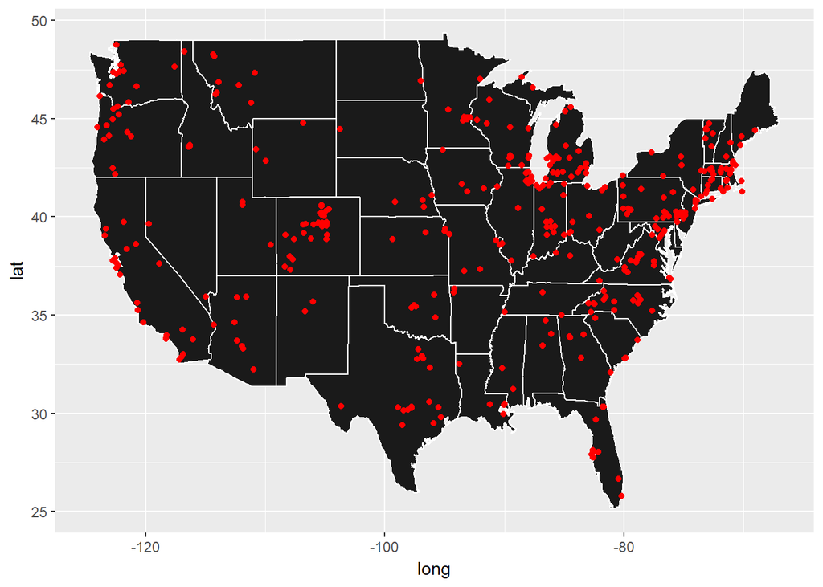

```r
library(ggplot2)
library(maps)
Lat_Long<-read.csv("MAINLAND_BREWERIES_DISTINCT_STATE_CITY.csv", sep = ",", header = TRUE, stringsAsFactors = TRUE)

all_states <- map_data("state")

ggplot() +
  geom_polygon( data=all_states, aes(x=long, y=lat, group = group),colour="white", fill="grey10" ) +
  geom_point( data=Lat_Long, aes(x=Long, y=Lat), color="red")
```

As you can see, there are a ton along the east coast in the Massachusetts, Delaware area. And I just realized you might not know which 2 states those are on the map. That’s ok, we have a list of the states with the most breweries in them.

```r
library(magrittr)
library(dplyr)
Breweries_Per_State<-Breweries %>% group_by(State) %>% summarise(Count_By_State = length(State))
Breweries_Per_State_Sort_DSND <- Breweries_Per_State[order(-Breweries_Per_State$Count_By_State),]
head(Breweries_Per_State_Sort_DSND)
```

```
## # A tibble: 6 x 2
##    State Count_By_State
##   <fctr>          <int>
## 1     CO             47
## 2     CA             39
## 3     MI             32
## 4     OR             29
## 5     TX             28
## 6     PA             25
```

If you’re unfamiliar, CO is Colorado, which is located slightly west of the center of the map and is the one with the clusters of breweries, 47 to be exact! We don’t recommend you go to all 47, so let’s dwindle this down a little more and give you a list of which cities in Colorado have the most beers on our list.

```r
col <- Breweries_Beers[ grep("CO",Breweries_Beers$State), ]
nrow(col)
```

```
## [1] 265
```

```r
BeersPerCity <- col %>% group_by(City) %>% summarise(BeersInCity = length(City))
sortCity <- BeersPerCity[ order(BeersPerCity$BeersInCity,decreasing=TRUE), ]
head(sortCity)
```

```
## # A tibble: 6 x 2
##           City BeersInCity
##         <fctr>       <int>
## 1      Boulder          41
## 2       Denver          40
## 3     Longmont          33
## 4 Fort Collins          22
## 5        Eagle          19
## 6      Durango          16
```

So we recommend you get on your broom and fly straight to Boulder, as you’ll have 41 different beers to choose from. While you’re there, we highly recommend you check out Upslope Brewing Company and try their Lee Hill Series Vol. 5 - Belgian Style Quadrupel Ale, as it has an ABV of 0.128, the highest ABV we have in our database! A drink with that much alcohol is almost like a wine, which you may enjoy as we remember you saying you’re a wine drinker too.

Once you’re done drinking all 41 beers in Boulder, hop in an Uber or the wizard equivalent (do not fly drunk Professor!) out to Denver and try the 40 beers there.

```r
sortedByABV <- Breweries_Beers[ order(Breweries_Beers$ABV, decreasing=TRUE), ]
sortedByABV[1,c(2,3,4,5,7)]
```

```
##                     Brewery    City State Region Beer_ID
## 384 Upslope Brewing Company Boulder    CO   WEST    2565
```

### Circle the Rest of the USA.

We’ve heard you’re a fan of butterbeer, so maybe you’ll also enjoy bitter beer. The most bitter beer in our database is the Bitter Bitch Imperial IPA found at the Astoria Brewing Company in Astoria, Oregon. It has a whopping 138 IBU! This will for sure test your taste buds.

```r
sortedByIBU <- Breweries_Beers[ order(Breweries_Beers$IBU, decreasing=TRUE), ]
sortedByIBU[1,c(2,3,4,5,7,8)]
```

```
##                      Brewery    City State Region Beer_ID   ABV
## 1857 Astoria Brewing Company Astoria    OR   WEST     980 0.082
```

```r
Median_IBU_Per_State<-Breweries_Beers %>% group_by(State) %>% summarise(Median_IBU_By_State = median(IBU,na.rm=TRUE))
Median_IBU_Per_State_CompleteCases<-na.omit(Median_IBU_Per_State)
sortedMedianIBU <- Median_IBU_Per_State_CompleteCases[ order(Median_IBU_Per_State_CompleteCases$Median_IBU_By_State,
                                                             decreasing=TRUE), ]
head(sortedMedianIBU)
```

```
## # A tibble: 6 x 2
##    State Median_IBU_By_State
##   <fctr>               <dbl>
## 1     ME                61.0
## 2     WV                57.5
## 3     FL                55.0
## 4     GA                55.0
## 5     DE                52.0
## 6     NM                51.0
```

Now that you’ve got a good idea on the taste of beers and a grasp on the bitterness, it’s time to (finally) get drunk. Luckily the place with the highest median ABV is just a quick Apparition spell away in Washington DC. The median ABV out there is 0.0625 (tied with Kentucky), a little higher than the overall median of 0.056.

```r
Median_ABV_Per_State<-Breweries_Beers %>% group_by(State) %>% summarise(Median_ABV_By_State = median(ABV,na.rm=TRUE))
Median_ABV_Per_State_CompleteCases<-na.omit(Median_ABV_Per_State)
sortedMedianABV <- Median_ABV_Per_State_CompleteCases[ order(Median_ABV_Per_State_CompleteCases$Median_ABV_By_State,
                                                             decreasing=TRUE), ]
head(sortedMedianABV)
```

```
## # A tibble: 6 x 2
##    State Median_ABV_By_State
##   <fctr>               <dbl>
## 1     DC              0.0625
## 2     KY              0.0625
## 3     MI              0.0620
## 4     NM              0.0620
## 5     WV              0.0620
## 6     CO              0.0605
```

You’ve travelled to 3 different states and our nation’s capital, but there are still 47 other states to visit. Instead of us telling you where you should go next, we’ll just give you a couple bar graphs with each state’s median ABV and IBU so you can decide where you’re off to. As you can see, aside from Utah (who have regulations), most states have fairly comparable ABVs, but there is a decent spread in differences in IBU.

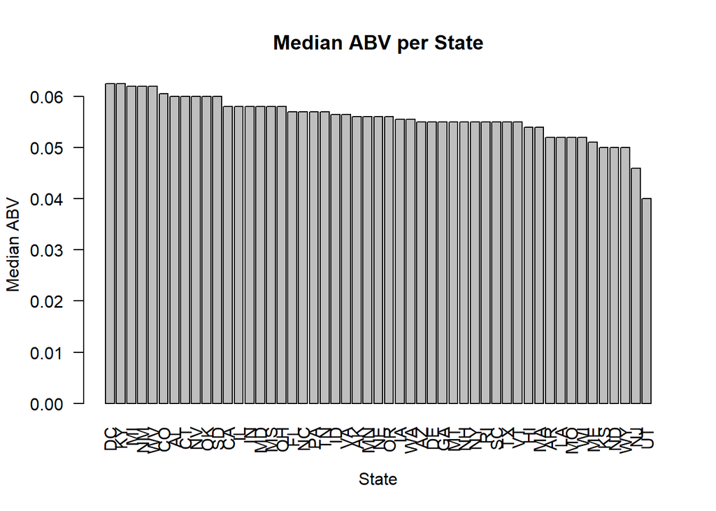

```r
barplot(sortedMedianABV$Median_ABV_By_State, names.arg = sortedMedianABV$State,las=2,
        main = "Median ABV per State", ylab = "Median ABV", xlab = "State")
```

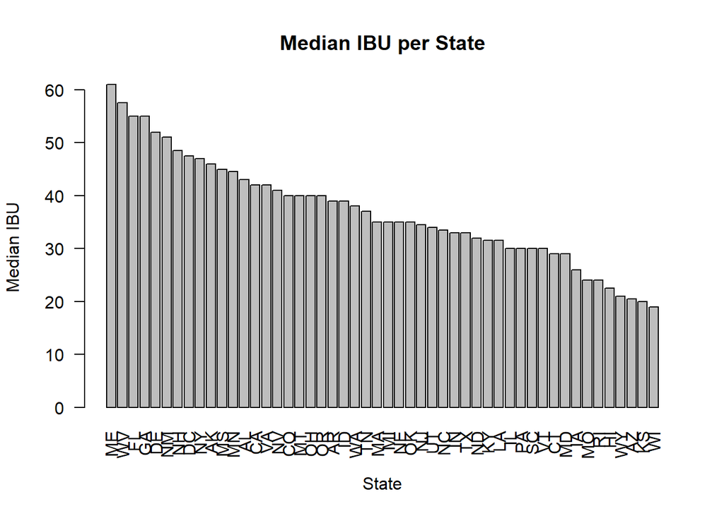

```r
barplot(sortedMedianIBU$Median_IBU_By_State, names.arg = sortedMedianIBU$State,las=2,
        main = "Median IBU per State", ylab = "Median IBU", xlab = "State")
```

If you’ve found that you like a certain region of the US better than others, fear not as our data suggests there isn’t much difference in the beers you’ll find in different regions. You can see the different regions scatter plots of ABV vs. IBU.

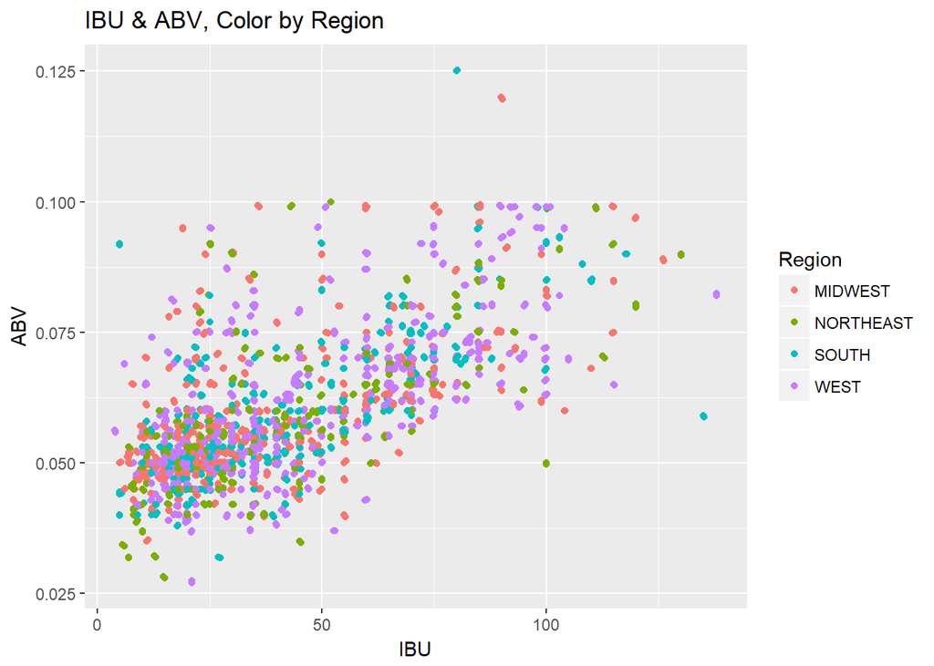

```r
library(ggplot2)

complete <- Breweries_Beers[complete.cases(Breweries_Beers), ]  ## Remove the NAs
ggplot(complete, aes(IBU, ABV, color=Region)) +
  geom_jitter() +
  geom_point() +
  ggtitle("IBU & ABV, Color by Region")
```

And also in their separated box plots. They each have similar heights and widths.

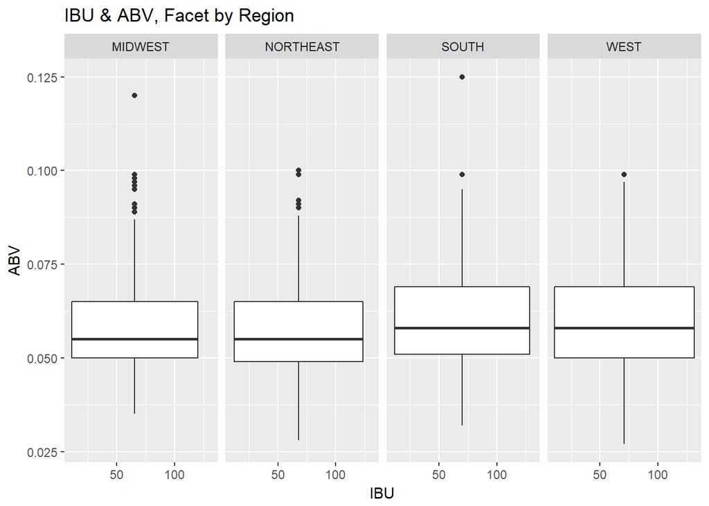

```r
ggplot(complete, aes(IBU, group=Region, ABV)) +
  geom_boxplot() +
  ggtitle("IBU & ABV, Facet by Region") +
  facet_wrap(~Region, nrow =  1)
```

After looking at those plots, you maybe asking youself “is there a correlation between ABV and IBU?” Why yes, there is! We’ve found that about 45% of the variance in IBU can be explained by the variance in the ABV. In lamens terms it basically means that while there is a direct correlation, every 6% beer won’t have the exact same IBU. On average, for every 0.1% ABV higher the beer is, the IBU increases by 1.282. Visually you can see what it means below.

```r
Cor_Bitt_IBU<-cor(Breweries_Beers$IBU, Breweries_Beers$ABV, use = "pairwise.complete.obs", method="pearson")
Cor_Bitt_IBU^2
```

```
## [1] 0.4497332
```

```r
library(faraway)
```

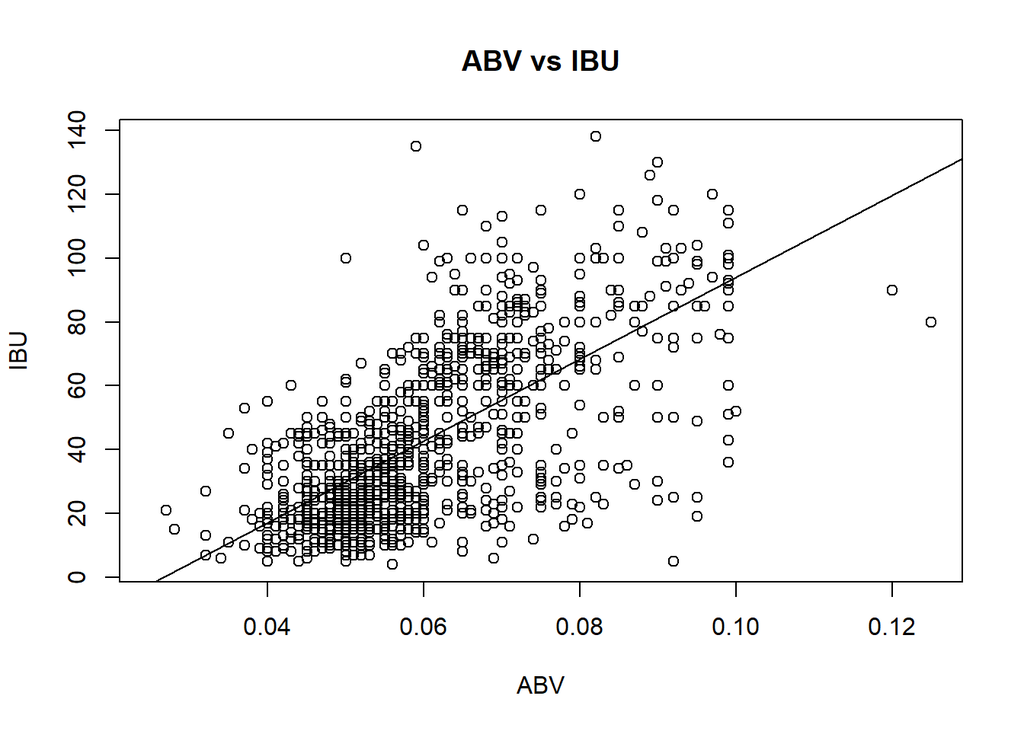

```r
plot(IBU~ABV, data=Breweries_Beers, xlim = c(.025, .125), main = "ABV vs IBU")
m<-lm(IBU ~ ABV, data=Breweries_Beers)
abline(m)
```

```r
m
```

```
##
## Call:
## lm(formula = IBU ~ ABV, data = Breweries_Beers)
##
## Coefficients:
## (Intercept)          ABV
##       -34.1       1282.0
```

That’s all we have for you today, Professor, but we’d love to work with you again in the future. If you need help organizing your potions database, please don’t hesitate to ask. If you find yourself in Texas on your beer journey, hit up Bruce and I’m sure he’ll grab a beer with you. I’m more of a wine guy myself.

Thanks again!

-Granger && Landrum LLC